# The Economic Burden of Disability in India: Estimates From the National Sample Survey (NSS) Data

Lakshmi K. Raut[^1], Manoranjan Pal and Premananda Bharati[^2]

September 29, 2018

Abstract

#### **Acknowledgements and disclaimer**

The views, thoughts, and opinions expressed in the paper belong solely to the authors, and do not necessarily represent the views of any organization, group or individual.

# 1 Introduction

In this paper, we estimate the economic cost to families with disabled members when a working family member loses job because of disability. We use the special module on disability of the 2002 NSS (National Sample Survey) dataset to estimate the cost. We also review the policy debates on disability in developing countries, and to improve the welfare of workers who lose jobs because of disability, we propose a self-financed publicly provided social disability insurance program that taxes the workers while in good health and working, and pay benefits when a worker becomes disabled and loses job. To put the policy debates in proper perspective, it is important to know how prevalent various types of disabilities are in less developed countries, what their causes and costs are. We can then evaluate the costs and benefits of public health policies that prevent or reduce the occurrence of disabilities, disability social insurance programs that provide disability benefits to those who lose jobs because of disability, and public policies that improve educational attainment or employment of the disabled.

It is difficult to compare prevalence of disability in the world as the definition of disability that the commonly available data sources use varies among the countries and even to compare prevalence within a country over time the definition varies.  
The cross-country estimates of disability rates are not comparable, since each country uses different definition of disability. Still to get some ideas about the disability incidence rates across countries, some attempts are made to have a common definition across countries such as Daniel Mont (2007)[^3]. Study by Daniel Mont (2007) shows that the disability rates are as high as around $20$ percent in New Zealand, Australia and the US, and as low as $2.1$ percent in India and even lower rates of $0.8$ percent in Bangladesh and $0.7$ percent in Kenya.

Public debates on disability policies fall into three categories: (i) preventive policies which include policies on public health, especially polio vaccination and prenatal and postnatal care, workplace safety, cleaning up of mine fields, and public awareness education, (ii) policies to reduce ‘earnings handicap’ (defined below) which include easier accessibility of the disabled person to schools and workplaces, and the prevention of discrimination against disabled persons in schools and in the labor market, (iii) policies to reduce ‘conversion handicap’ (defined below), which include providing resources for wheel chairs, prosthesis or other such special needs to the disabled.

Sen (2004) in his address states:

> “It is also, I would argue, useful to understand why the main schools of thought in theories of justice have tended to neglect this central issue, and how that neglect, in its turn, has tended to bias practical policies in the direction of inaction, and has even contributed to suppressing the sense of inadequacy that can reasonably accompany the failure to take a responsible view of the social obligation to the disabled.”

He suggests extending the existing theories of justice for income distribution to incorporate the ‘earnings handicap’ and ‘conversion handicap’ of the disable people. He defines those two types of handicaps as follows: To achieve the same level of opulence a “disabled person may find it harder to get a job or to retain it, and may receive lower compensation for work.’’ This refers to ‘earnings handicap’. On top of the earnings handicap, to”do the same things as an able-bodied person, a person with physical disability may need more income than the able-bodied person. To move easily or at all, a person who happens to be, say, crippled by an accident or by illness may need assistance, or prosthesis, or both. The conversion handicap refers to the disadvantage that a disabled person has in converting money into good living.”

Being guided by the ethical and moral discussions on redistribution, as advocated, for instance, by Sen (2004) or by the guidelines of the international health and development organizations such as the World Health Organization and the World Bank, or following some other principles of its own, India has introduced quite a few disability policies in all the above three areas. The achievements are, however, not satisfactory. A lot needs to be done to implement the existing policies or to introduce better policies. For instance, consider one important policy, the PWD (Person with Disability) Act of 1995 (see Trivedi (2011) for excerpts of the main items of this policy). The policy reserves a certain percentage of public sector jobs for disabled persons, yet there has been a decline in the employment rate of the working age disabled population from 43 percent in 1991 to 38 percent in 2002. Furthermore, the policy encompasses only seven denominated types of disability and fails to include cerebral palsy, muscular dystrophy and autism World Bank (2007).

One most important earnings handicap for disabled persons is low or no education. For instance, World Bank (2007) reports a much lower educational attainment rate in India: about 52 percent illiteracy rate among the disabled population compared to a 35 percent illiteracy rate among the general population. The percentage of disabled children who are out of school is around five and a half times higher than that for the general population. The disabled children in India are more deprived of education than even generally known deprived SC &ST (Scheduled Castes and Scheduled Tribes) population whose percentage of out of schoolchildren population is about four times higher than that of the general population. In even the best performing major states, significant shares of out of school children are those with disabilities: in Kerala, 27 percent; in Tamil Nadu over 33 percent, see World Bank (2007). Putting together estimates from survey data on 13 countries, Filmer (2008) found that the poorest of the poor is the disabled population, because they had the lowest or no education, leading to lowest earnings in the labor market and thus to poverty. Controlling for other variables, his econometric estimates show that if disabled individuals attain the same level of education as the normal children, there will be no difference between the disabled and non-disabled persons as far as the opulence i.e. income is concerned. It is important to note however that policies to educate the disable is only a necessary step for equality of opulence between disabled and non-disabled individuals, the labor market policies such as discrimination against disabled workers and making the workplace accessible to disabled workers must also be introduced and properly implemented. Note that this can only equalize the opulence between the two groups. The disabled population still faces the Sen’s conversion handicap problem: equality of earnings of the able and disabled persons would not achieve equality of their living standards; more is to be done for the disabled population to achieve equity of living standard.

The disability policy discussions on India have focused on other areas such as provision of education for the disabled children, reservation of employment for the disabled persons, and provision of preventive cares such as universal coverage of polio vaccination and improvement of prenatal care. Those policies are useful but the implementation of those policies have been very unsatisfactory as can be seen from there being no improvement or even deterioration of disability incidence rates over time. For more meaningful policy discussions and recommendations, it is very important to know the magnitude of economic burdens to the family when a family member becomes disabled.

Disability imposes many types of economic burdens to the disabled individual, to the family of the disabled and more broadly to the employer, insurance companies and to the society. First, the family with a disabled member incurs extra expenses to meet the medical or equipment needs of a disable family member. Second, the individual with disability will end up contributing very little or nothing to the family resources due to presenteeism, i.e., lower productivity due to working while disabled, and due to absenteeism, i.e., total loss of job or reduction in the number of work hours due to disability. Third, the disability of the individuals can have many negative effects on their employers, insurance companies and society in terms of lost profits, higher medical expenses and maintenance of transportation and building infrastructures required to accommodate the disabled.

Not much is known about the magnitude of the medical costs of a disease or disability in developing countries. In developed countries, a few studies estimate medical costs and loss in earnings due to some diseases and disabilities, see for instance, (Leibson et al. 2001; Swensen et al. 2003; Goetzel et al. 2004; Wild et al. 2004; Dall et al. 2010; Mitchell and Bates 2011) and see Zhang, Bansback, and Anis (2011) for a review of measurement issues in this area.

Disability of a family member affects the standard of living of the family. A disabled person has to incur extra expenses to convert a level of income to achieve the similar standard of living that a normal person can achieve. Sen (2004) names these extra expenses as *conversion handicap*. In addition to the conversion handicap expenses, the disabled person may lose days of work or may have lower productivity because of disability or may simply loses job. All these will lead to lower family income and lower consumption. Furthermore, other family members may have to cut down their work hours to take care of the disabled family member, reducing further the total family resources. Thus, on the one hand, the consumption will rise due to conversion handicap and on the other hand, the consumption will fall due to drop in the family resources. The net effect is to be empirically estimated, which we do in this paper using the NSS dataset.

Zaidi and Burchardt (2005) introduced an empirical technique to estimate the magnitude of conversion handicap[^4], i.e., to attain the same level of living standard, how much extra earnings a disabled person would need compared to a non-disabled person. This technique has been applied to a few studies on developed countries: Zaidi and Burchardt (2005) provided estimates of these extra costs in the UK, Saunders (2007) for Australia,Cullinan, Gannon, and Lyons (2011) for Ireland. Similar studies on developing countries are very limited due to paucity of appropriate date. See, however, Kandamuthan and Kandamuthan (2004) for India, Braithwaite and Mont (2009) for Bosnia and Vietnam, D. Mont and Cuong (2011) for Vietnam, and Loyalka et al. (2014) for China. The estimation of the cost of disability is a very important policy research issue because it can gauge the costs and benefits of various disability preventive policies.

A disability insurance program, private or public, is required to reduce the welfare losses of families with disability. Private disability insurance programs are very rare even in developed countries where insurance markets are well developed. When they exist, they have limited coverage due to moral hazard and adverse selection problems associated with disability. To overcome these market failures, most developed countries have introduced publicly provided disability insurance programs, which are further justified ethically using the Rawlsian theory of redistributive justice. For instance, in the US, the disability insurance component of the OASDI (Old Age Security and Disability Insurance) program collects taxes from a worker while working and provides substantial percentage of his average pre-retirement earnings as disability benefits if he becomes disabled and applies for disability benefits. The program improves everybody’s expected welfare under the Rawlsian veil of ignorance.[^5] We will see that our estimates are useful to get an idea about the kind of expected welfare gains that an Indian family can expect if such a program is introduced.

The rest of the paper is organized as follows. In section 2, I discuss the patterns of disability in India that are found by other studies using the census data and the NSS data. This section also describes the variables we use in our econometric analysis. In section 3, we describe the patterns of job loss because of onset of disability. In section 4, we estimate the effect of losing job because of onset of disability on the household ‘conversion handicap’ adjusted per capita consumption and discuss the policy implications and section 6 concludes the paper.

# 2 The disability patterns in India

## 2.1 The disability patterns in India

In India, two institutions are involved in the collection of national level data on the nature and magnitude of disability. These are National Sample Survey Organization (NSSO) and Census of India. Census of India collects data at regular ten years interval. It is a complete enumeration or census, aiming at collection of basic necessary data, which include information on disability among other things. Last census was taken in 2011 with the categories of disabilities are slightly enlarged. The previous census was taken in 2001. The following table gives at a glance the disability situation of India.

Table 2.1: Disability in India by gender and type of disability: 2001.

| Type of disability | Number of individuals | Male |  | Female |  |
| --- | --- | --- | --- | --- | --- |
|  |  | Number | Percent | Number | Percent |
| Vision | 10,634,881 | 5,732,338 | 45.5 | 4,902,543 | 52.7 |
| Speech | 1,640,868 | 942,095 | 7.5 | 698,773 | 7.5 |
| Hearing | 1,261,722 | 673,797 | 5.3 | 587,925 | 6.3 |
| Movement | 6,105,477 | 3,902,752 | 31 | 2,202,725 | 23.7 |
| Mental | 2,263,821 | 1,354,653 | 10.7 | 909,168 | 9.8 |
| Total | 21,906,769 | 12,605,635 | 100 | 9,301,134 | 100 |
| Source: Census of India. 2001 |  |  |  |  |  |

The above table shows that there are more female members with vision disability than male members, whereas in case of movement disability it is just the opposite. It is expected, because the male members usually work outside their home and they are more likely to be victim of accidents leading to movement disability.

NSSO collects data on household consumption every year by taking representative samples of households from all regions of the country. These are called rounds. In approximately every fifth year, the size of the sample is enhanced in order to get more efficient estimates of the population parameters. These rounds are called quinquennial rounds. Data on employment are also collected every year. Besides, special surveys are conducted from time to time to collect information on other aspects like disability, slum dwellers, child workers etc. Last disability survey was conducted in 2002 ($58^{th}$ Round). Since the year 2002 is close to 2001 when the census was taken, we have the opportunity to compare the two figures. This is given in the following table:

Table 2.2: Percentage distribution of disabled persons in India by type of disability.

| Type of Disability | Census 2001 | NSSO 2002 | Our sample |
| --- | --- | --- | --- |
| Vision | 49 | 14 | 17 |
| Speech | 7 | 10 | 3 |
| Hearing | 6 | 15 | 14 |
| Movement | 28 | 51 | 57 |
| Mental | 10 | 10 | 10 |
| Total | 100 | 100 | 100 |
| Source: National Sample Survey Organizations, 2002. Last column is authors' calculation from the sample. |  |  |  |

It is clear from Table 2.2 that the two definitions of disability, rather types of disability, do not match. Census 2001 arrives at the figure of visually disabled person as $49$ percent which is much higher than $14$ percent found by NSSO. There are vast differences in the figures of movement disability also. Absolute figures also differ much. Total number of disabled persons in Census of India (2001) is about $4$ times larger than that of NNSO National Sample Survey Organization (2002) estimate.

Census of India admits that there are difficulties in defining and measuring disability and therefore used its own definitions of disabilities. According to NSSO, restrictions or lack of abilities to perform a normal activity assumed to be of permanent nature is termed as disability. The reasons for differences will be clearer if we explore the definitions type by type. The Census of India defined disability as (i) being completely blind or having blurred vision even with the help of spectacles. Impaired vision in only one eye is also treated as visual disability. Even a person, who has not tested his/her eyes and is having blurred vision without spectacles, is treated as visually disabled. NSSO, however, defines a person to be visually disabled if he/she does not have any light perception in both eyes even with spectacles/contact lances. Night blindness is not considered by NSSO as visual disability. The above discussion makes it clear why NSSO visual disability estimate is so low compared to census figure.

The reasons for differences in figures in other types of disability can be similarly traced in the respective definitions. We shall not go into the details of it, since we shall deal with only NSSO data and have no intention of comparing our estimates with those of census estimates.

Disability is closely related to poverty and backwardness. It has been found that there are comparatively more disabled persons in rural areas and in underdeveloped states Census of India (2001).

It should be mentioned here that there may be overlapping, i.e., with more than one disability. The counts in Table 2.1 and Table 2.2 take only the primary disability as reported by the respondent. The following table will make the idea clear.

Table 2.3: Prevalence of disability in India by type of disability and place of residence.

| Regions | Sex | Number of PWD | At Least One Disability | Visually Impaired | Hearing Impaired | Speech Disability | Locomotors Disability | Overlapping |
| --- | --- | --- | --- | --- | --- | --- | --- | --- |
| Urban | Male | 4,950 | 2,078 | 308 | 339 | 298 | 1,370 | 557 |
|  | Female | 3,473 | 1,424 | 362 | 330 | 169 | 762 | 426 |
|  | Total | 8,423 | 41.58% | 7.94% | 7.94% | 5.50% | 25.30% | 11.67% |
| Rural | Male | 17,737 | 7,442 | 1,539 | 1,409 | 942 | 4,396 | 2,009 |
|  | Female | 12,628 | 5,210 | 1,796 | 1,164 | 557 | 2,411 | 1,490 |
|  | Total | 30,365 | 41.67% | 10.98% | 8.47% | 4.90% | 22.42% | 11.52% |
| Source: National Sample Survey Organization (1997). |  |  |  |  |  |  |  |  |

Table 2.3 shows that there is not much rural-urban difference so far as disability is concerned. Rather male-female differences are bigger.

Causes of disability are specific to the type of disability. E.g., visual disability may be because of old age, cataract, eye discharge, glaucoma, injury, diarrhoea (for under age $6$ children), etc. It is surprising to note that about $3$ percent of visual disability in India is due to small pox.

The earnings of a person may have a link with the disability. But the earnings data are very difficult to collect in India. So NSSO does not collect earnings data. Instead it collects data on consumer expenditure at the household level. Consumer expenditure is taken as a proxy for the income of the household. Consumer expenditure is also found to be more stable than income because over time people develop stable habits of consuming particular types of commodities and their quantities. Income data have more fluctuations. Changes in income do not immediately influence significant changes in the types and the quantities of consumption. Thus, we use the per capita household consumer expenditures data collected by NSSO to measure the cost of disability when a person loses job because of disability. Our data is on households with a disabled member. So the consumption expenditures for all households already include the extra ‘conversion handicap’ amount. Thus, our estimate of consumption loss due to job loss will be for the ‘conversion’ handicap adjusted consumption.

Our main variable, the household per capita consumption is defined as follows in the NSSO report. “Household consumer expenditure is measured as the expenditure incurred by a household on domestic account during a specified period, called reference period. It also includes the imputed values of goods and services, which are not purchased but procured for consumption. In other words, it is the sum total of monetary values of all the items (i.e. goods and services) consumed by the household on domestic account during the reference period. The imputed rent of owner-occupied houses is excluded from consumption expenditure. Any expenditure incurred towards the productive enterprises of the households is also excluded from the household consumer expenditure. Monthly per capita expenditure (MPCE) is the household consumer expenditure over a period of 30 days divided by household size. A person’s MPCE is understood as that of the household to which he/she belongs.”

We define the Work Loss variable as taking value $1$ if a family member was working before the onset of his disability and lost work after the onset of disability, and taking value $0$ otherwise.

NSSO collected data on general education attained by disabled family members under the categories: not literate, literate without formal schooling, literate but below primary, primary, middle, secondary, higher secondary, diploma/certificate course, graduate, post graduate and above. We created our binary variable Higher Education to take value $1$ if the education level is Higher Secondary or above and $0$ otherwise.

We summarize our variables in the following table.

Table 2.4: Definition of variables.

| Work Loss | = 1 if lost work due to disability, else = 0 |
| --- | --- |
| Higher Education | = 1 if Higher Sec. or above, else =0 |
| Household Size | Household size |
| Age at Disability Onset | Age at the onset of disability |
| Number of Disabilities | The number of disabilities |
| Caste | = 1 if backward class, else = 0 |
| Place of Residence | = 1 if Rural, else = 0 |

Table 2.5: Characteristics of work loss in the sample.

| Group | Number of disabled people in the sample | Percent lost work | Average monthly consumption of those who did not lose job | Average monthly consumption of those who lost job | Difference in percent of average monthly consumption |
| --- | --- | --- | --- | --- | --- |
| Overall | 50,464 | 48.99 | 597 | 546 | 8.50 |
| Lower Education | 47,513 | 49.52 | 567 | 520 | 8.15 |
| Higher Education | 2,951 | 40.60 | 1,008 | 1,048 | -3.98 |
| Upper Class | 16,423 | 47.22 | 740 | 678 | 8.37 |
| Lower Class | 34,041 | 49.85 | 524 | 486 | 7.31 |
| Urban | 18,545 | 41.75 | 769 | 720 | 6.32 |
| Rural | 31,919 | 53.20 | 472 | 466 | 1.19 |
| High Income States | 8,661 | 48.79 | 715 | 639 | 10.68 |
| Middle Income States | 14,759 | 46.44 | 626 | 549 | 12.30 |
| Low Income States | 19,963 | 49.48 | 492 | 467 | 5.11 |
| By Disability Type |  |  |  |  |  |
| Mental | 5,175 | 51.11 | 612 | 514 | 16.02 |
| Visual | 8,452 | 62.25 | 557 | 488 | 12.36 |
| Hearing | 6,892 | 54.30 | 644 | 562 | 12.70 |
| Speech | 1,278 | 31.22 | 603 | 594 | 1.49 |
| Locomotors | 28,667 | 44.22 | 592 | 570 | 3.75 |
| Source: Authors' calculation. |  |  |  |  |  |

We dropped observations that have missing information on any of the variables in the above table. We ended up with a sample size of 50,464 households with a disabled member.

# 3 Patterns of job loss because of disability

NSSO collected data on whether the disabled person was working before the onset of disability. According to their estimates see Statement $16$ in National Sample Survey Organization (2003), about 37 per cent of the age 5 and above disabled population were working before the onset of disability. For our sample, we report in Table 2.5 the percentage of disabled individuals who lost work due to onset of disability and the average monthly per capita consumption expenditures of households with disabled members who lost job and with disabled members who did not lose job. We report these statistics for the overall sample, and its various subgroups.

In our overall sample, about $49$ percent lost work after onset of disability. The percentage of disabled individuals who lost job is higher among the disabled members with lower education, lower caste, lower income states and living in rural areas. Among the types of disability, the visual disability led to highest rate of job loss, about $62$ percent, and the speech disability led to the lowest rate of job loss, about $31$ percent. The loss of jobs led to about 8.5 percent lower average per capita household monthly consumption expenditures for the overall sample, and for most its subgroups, the losses are close to the loss of the overall sample, with the striking differences for the higher education group, for whom the loss of job increased per capita consumption by about 4 percent, and for the rural households, for whom the drop in consumption is very small, about $1$ percent. There are large variations in the loss of consumption for various types of disability: the drop in per capita consumption expenditure is the highest, about 16 percent, for mental disability, and the lowest, about $1.49$ percent for the speech disability.

## 3.1 Job loss because of onset of disability by state

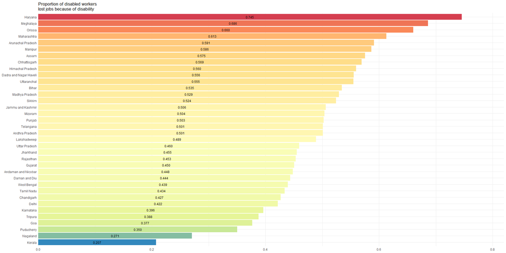

Figure 3.1: The rate of job loss because of disability by state

# 4 The effect of job loss on per capita household consumption

Disability of a family member involves extra expenditures to cover medical cares and equipment requirements for the disability member to manage his daily living - known as ‘conversion handicap’ in Sen’s terminology. On top of the conversion handicap, if the disabled member loses job at the onset of his disability, the total resources available for the family to spend becomes smaller. This would further reduce the well-being of the family. The burden of disability will be the sum of the two. We cannot get an estimate of the extent of ‘conversion handicap’ in India from our dataset since it does not have a nationally representative sample of households without disability to match with the households with disability. However, we can estimate the latter cost, since our dataset consists of households with a disabled member, and contains information on if a member lost job due to onset of disability. To that end, we estimate the percentage loss in household per capita consumption of households with a disabled member when the disabled member loses job due to onset of disability. We use a fixed effect regression model as follows:

$$\ln (c_{ij} )=\alpha _{i}S_i+\gamma_i (S_i\times Workloss_{ij}) +\beta 'X_{ij} +\epsilon _{ij},$$
where $S_i$ is the dummy variable for state $i$ and $\gamma_i$ a parameter representing the change in consumption in state $i$ if a disabled worker in that state lose job because of disability, $X_{ij}$ is a $k$ dimensional vector of characteristics excluding the Workloss variable[^7] of the individual $j$ in state $i$, $\beta$ is a k dimensional vector of parameters, and $\alpha _{i}$ is the fixed effect of state $i$. One of the right hand side variables is the binary variable Work Loss, and the interpretation of the corresponding $\beta$ is that controlling for other variables, if a disabled member loses job due to the onset of his disability, the percentage change in per capita consumption is $\beta$.

If we had the earnings data on individuals, we could estimate the loss in earnings due to disability but no earnings data are available in India. So we use consumption data to estimate the cost.

The number of disabilities of a disabled member, measuring the severity of disability, can further lower the loss in per capita household consumption by 2 percent for each extra disability. This effect is lower for a rural household, 2 percent, and higher for an urban household, 3 percent.

Table 4.1: Regression estimates of per capita consumpion loss for households with disable members when a disabled member loses job by state.

| State | number of households | percent lost work | parameter estimate | t-value |
| --- | --- | --- | --- | --- |
| Jammu & Kashmir | 1,483 | 22.25 | -0.074 * | -2.04 |
| Himachal Pradesh | 1,278 | 32.86 | 0.032 | 0.94 |
| Punjab | 2,275 | 18.68 | -0.1 *** | -3.29 |
| Chandigarh | 165 | 14.55 | -0.088 | -0.62 |
| Uttaranchal | 679 | 14.43 | -0.116 * | -1.99 |
| Haryana | 1,651 | 16.29 | -0.004 | -0.09 |
| Delhi | 569 | 7.91 | 0.09 | 1.07 |
| Rajasthan | 3,502 | 18.13 | -0.055 * | -2.03 |
| Uttar Pradesh | 11,100 | 18.87 | -0.041 ** | -2.70 |
| Bihar | 5,433 | 17.23 | -0.081 *** | -3.96 |
| Sikkim | 744 | 8.47 | -0.058 | -0.81 |
| Arunachal Pradesh | 307 | 10.10 | 0.138 | 1.46 |
| Nagaland | 408 | 10.29 | -0.066 | -0.84 |
| Manipur | 983 | 22.48 | 0.032 | 0.76 |
| Mizoram | 518 | 12.93 | 0.118 | 1.78 |
| Tripura | 1,020 | 9.31 | -0.106 | -1.89 |
| Meghalaya | 684 | 13.89 | -0.042 | -0.71 |
| Assam | 1,923 | 15.91 | -0.014 | -0.42 |
| West Bengal | 7,587 | 13.47 | -0.128 *** | -6.87 |
| Jharkhand | 1,735 | 15.85 | 0.086 * | 2.21 |
| Orissa | 3,206 | 29.04 | -0.042 | -1.78 |
| Chhatisgarh | 1,469 | 22.19 | -0.011 | -0.29 |
| Madhya Pradesh | 4,434 | 19.10 | -0.037 | -1.58 |
| Gujarat | 2,995 | 13.49 | -0.136 *** | -4.18 |
| Daman & Diu | 213 | 18.78 | -0.036 | -0.31 |
| Dadra & Nagar Haveli | 200 | 17.00 | -0.02 | -0.17 |
| Maharashtra | 7,835 | 21.60 | -0.125 *** | -7.26 |
| Andhra Pradesh | 6,559 | 22.88 | -0.106 *** | -5.22 |
| Karnataka | 3,660 | 17.05 | -0.059 * | -2.15 |
| Goa | 175 | 12.57 | 0.039 | 0.30 |
| Lakshadweep | 259 | 4.25 | -0.219 | -1.34 |
| Kerala | 3,649 | 15.51 | -0.016 | -0.55 |
| Tamilnadu | 7,182 | 16.62 | -0.114 *** | -5.95 |
| Pondicherry | 597 | 14.91 | -0.002 | -0.02 |
| Andaman & Nicobar Island | 268 | 6.34 | -0.033 | -0.28 |
| *** p < 0; ** p < 0; * p < 0. |  |  |  |  |

Table 4.2: Regression estimates of per capita consumpion loss for households with disable members when a disabled member loses job by state.

| StateName | pct_lostjob | pcmexp_dib_hhld | pcmexp_nojobloss | pcmexp_jobloss | pct_loss_work | Estimate | t.value |
| --- | --- | --- | --- | --- | --- | --- | --- |
| Andaman & Nicobar Island | 26.15 | 923 | 906 | 709 | -21.74 | -3.287 | -0.27 |
| Andhra Pradesh | 67.89 | 546 | 572 | 490 | -14.34 | -10.605 *** | -5.22 |
| Arunachal Pradesh | 23.48 | 475 | 421 | 392 | -6.89 | 13.761 | 1.46 |
| Assam | 39.18 | 530 | 532 | 508 | -4.51 | -1.355 | -0.42 |
| Bihar | 49.52 | 404 | 424 | 391 | -7.78 | -8.06 *** | -3.97 |
| Chandigarh | 61.54 | 1,004 | 1,310 | 982 | -25.04 | -8.812 | -0.62 |
| Chhatisgarh | 59.93 | 447 | 426 | 442 | 3.76 | -1.115 | -0.29 |
| Dadra & Nagar Haveli | 60.71 | 1,000 | 1,268 | 870 | -31.39 | -2.009 | -0.17 |
| Daman & Diu | 66.67 | 841 | 926 | 748 | -19.22 | -3.608 | -0.31 |
| Delhi | 42.06 | 1,008 | 1,023 | 1,219 | 19.16 | 8.977 | 1.07 |
| Goa | 51.16 | 729 | 1,088 | 742 | -31.80 | 3.942 | 0.31 |
| Gujarat | 55.04 | 669 | 766 | 610 | -20.37 | -13.618 *** | -4.18 |
| Haryana | 55.46 | 709 | 782 | 709 | -9.34 | -0.359 | -0.09 |
| Himachal Pradesh | 59.32 | 688 | 661 | 676 | 2.27 | 3.193 | 0.94 |
| Jammu & Kashmir | 55.46 | 776 | 841 | 726 | -13.67 | -7.363 * | -2.04 |
| Jharkhand | 50.93 | 457 | 458 | 512 | 11.79 | 8.611 * | 2.21 |
| Karnataka | 57.72 | 521 | 547 | 494 | -9.69 | -5.886 * | -2.15 |
| Kerala | 59.83 | 661 | 671 | 652 | -2.83 | -1.586 | -0.55 |
| Lakshadweep | 36.67 | 696 | 805 | 726 | -9.81 | -21.911 | -1.34 |
| Madhya Pradesh | 58.62 | 441 | 454 | 418 | -7.93 | -3.733 | -1.58 |
| Maharashtra | 62.34 | 618 | 626 | 522 | -16.61 | -12.519 *** | -7.26 |
| Manipur | 49.11 | 554 | 534 | 576 | 7.87 | 3.205 | 0.76 |
| Meghalaya | 36.40 | 640 | 665 | 635 | -4.51 | -4.172 | -0.72 |
| Mizoram | 33.33 | 881 | 845 | 939 | 11.12 | 11.781 | 1.78 |
| Nagaland | 30.00 | 884 | 914 | 830 | -9.19 | -6.642 | -0.84 |
| Orissa | 61.74 | 369 | 364 | 342 | -6.04 | -4.178 | -1.78 |
| Pondicherry | 63.57 | 667 | 638 | 635 | -0.47 | -0.182 | -0.02 |
| Punjab | 52.61 | 794 | 816 | 742 | -9.07 | -10.028 *** | -3.29 |
| Rajasthan | 59.46 | 532 | 545 | 520 | -4.59 | -5.522 * | -2.03 |
| Sikkim | 38.65 | 522 | 525 | 498 | -5.14 | -5.821 | -0.81 |
| Tamilnadu | 57.76 | 636 | 674 | 552 | -18.10 | -11.448 *** | -5.95 |
| Tripura | 35.45 | 563 | 557 | 533 | -4.31 | -10.596 | -1.89 |
| Uttar Pradesh | 58.73 | 466 | 500 | 462 | -7.60 | -4.062 ** | -2.70 |
| Uttaranchal | 44.34 | 556 | 604 | 514 | -14.90 | -11.634 * | -1.99 |
| West Bengal | 45.24 | 552 | 584 | 480 | -17.81 | -12.85 *** | -6.87 |
| *** p < 0; ** p < 0; * p < 0. |  |  |  |  |  |  |  |

Figure 4.1 shows only the statistically significant estimates of the percentage of loss in consumption because of disability from table 4.1, ordered by the magnitude.

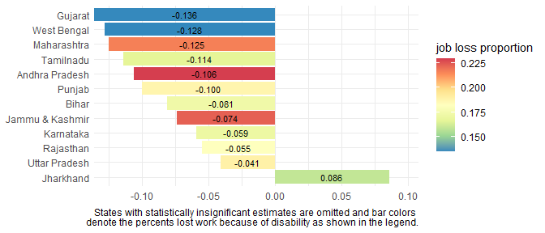

Figure 4.1: Estimated percentage change in per capita consumption from job loss because of disability.

Table 4.3 shows the parameter estimates that are common across states.

Table 4.3: Parameter estimates of the covariates common across all states

[output not shown]

The estimates of the regressors common to all states are given in Table 4.3.

## 4.3 The cost of losing job because of disability by region

Following administrative criterion[^8], we group Indian states into seven regions and examine the variations of the cost of losing jobs among them. The regions are as follows:

- North: Chandigarh, Delhi, Haryana, Himachal Pradesh, Jammu and Kashmir, Ladakh, Punjab, and Rajasthan;
- North East: Assam, Arunachal Pradesh, Manipur, Meghalaya, Mizoram, Nagaland,Tripura and Sikkim;
- East: Bihar, Jharkhand, Odisha, and West Bengal;
- Central: Chhattisgarh, Madhya Pradesh, Uttarakhand and Uttar Pradesh;
- West: Dadra and Nagar Haveli and Daman and Diu, Goa, Gujarat, and Maharashtra;
- South: Andhra Pradesh, Karnataka, Kerala, Puducherry, Tamil Nadu, and Telangana.
- Islands: Andaman and Nicobar Islands, Lakshadweep.

Table 4.4: The effect of job Loss on household per capita consumption in different regions.

|  | North | North East | East | Central | West | South | Islands |
| --- | --- | --- | --- | --- | --- | --- | --- |
| Intercept | 6.704 *** | 6.643 *** | 6.318 *** | 6.477 *** | 6.708 *** | 6.483 *** | 7.221 *** |
|  | (0.034) | (0.067) | (0.028) | (0.040) | (0.037) | (0.026) | (0.165) |
| work Loss | -0.045 ** | -0.009 | -0.072 *** | -0.043 *** | -0.115 *** | -0.085 *** | -0.113 |
|  | (0.014) | (0.019) | (0.012) | (0.013) | (0.016) | (0.011) | (0.082) |
| Higher Education | 0.407 *** | 0.273 *** | 0.507 *** | 0.416 *** | 0.521 *** | 0.495 *** | 0.607 |
|  | (0.033) | (0.046) | (0.026) | (0.027) | (0.038) | (0.026) | (0.343) |
| Household Size | -0.039 *** | -0.040 *** | -0.027 *** | -0.035 *** | -0.027 *** | -0.043 *** | -0.043 *** |
|  | (0.002) | (0.004) | (0.002) | (0.002) | (0.003) | (0.002) | (0.011) |
| Age of Disability Onset | 0.002 *** | 0.001 | 0.001 *** | 0.001 *** | 0.001 * | 0.002 *** | -0.000 |
|  | (0.000) | (0.001) | (0.000) | (0.000) | (0.000) | (0.000) | (0.002) |
| Number of Disabilities | -0.012 | 0.007 | 0.024 | -0.042 ** | -0.042 * | -0.024 | -0.051 |
|  | (0.016) | (0.035) | (0.016) | (0.015) | (0.020) | (0.014) | (0.084) |
| Lower Caste | 0.248 *** | 0.055 * | 0.168 *** | 0.218 *** | 0.213 *** | 0.177 *** | -0.143 |
|  | (0.014) | (0.022) | (0.013) | (0.015) | (0.016) | (0.014) | (0.133) |
| Place of Residence | -0.198 *** | -0.322 *** | -0.376 *** | -0.250 *** | -0.355 *** | -0.290 *** | -0.290 *** |
|  | (0.015) | (0.024) | (0.014) | (0.014) | (0.015) | (0.011) | (0.077) |
| N | 3634 | 2100 | 5718 | 5457 | 3472 | 6173 | 93 |
| logLik | -1744.175 | -1210.162 | -3214.735 | -3200.389 | -2050.410 | -3287.210 | -23.142 |
| AIC | 3518.351 | 2452.324 | 6453.469 | 6424.779 | 4126.820 | 6600.420 | 66.285 |
| *** p < 0.001; ** p < 0.01; * p < 0.05. |  |  |  |  |  |  |  |

# 5 Discussions and Policy recommendation

Zaidi and Burchardt (2005) postulated that the living standard *LS* of an individual depends on his earnings *E*, disability status *D* and other factors as follows:

$$\begin{equation*}
LS= \alpha +\beta \ln E+\gamma D+...,
\end{equation*}$$

where $\alpha,\beta$ and $\gamma$ are parameters. Holding other factors constant, we have $\Delta LS=\beta \Delta E/E+\gamma \Delta D$. To have the same level of $LS$, i.e., $\Delta LS=0$, if $\Delta D>0$, i.e., if $D$ changes from $0$ to $1$, the associated percentage change in $E$ is given by $\Delta E/E=-\gamma /\beta$.

Loyalka et al. (2014) found the estimates of this extra cost for China to be in the range of $8$ to $43$ percent, depending on the number of adults in the households and the place of residence: the higher the number adults in the household or if the disabled person lives in the rural area, the lower is the cost of disability. Braithwaite and Mont (2009) estimated the extra cost of disability to be 9 percent for Vietnam and $14$ percent for Bosnia. D. Mont and Cuong (2011)) refined the Braithwaite and Mont analysis and estimated the cost of disability by the degree of disability and by the age of disability onset. After controlling for other factors, they estimated the cost to be around 13 percent if the onset is before age $18$. Our estimates of the cost of disability arising from losing job due to onset of disability are lower than these estimates from other countries. This is expected because we are estimating the cost arising from the loss of job for the households with a disabled member, for whom the average consumption is already lower than the households without any disabled member.

According to our estimates, the living standards as measured by per capita household expenditure of the households falls by 7 percent if the disabled member loses job due to onset of disability. A social insurance program can tax the working population and provide the disabled members who lose jobs a cash benefits to restore consumption close to what they were enjoying before losing job. This will reduce very little the consumption and hence the living standards of those who are working, but will reduce the huge loss in consumption and hence improve the living standards of the households whose members lose job due to onset of disabilities.

# 6 Conclusion

The entire exercise is carried out with the NSS data. As already noted, the definitions adopted by NSSO and Census differ widely, leading to much discrepancies in the percentages of disabled persons in different categories. Thus if the census data are used, the results may change substantially. We believe, however, that the conclusions will be similar even if census data are used.

A publicly provided actuarially fair social disability program that taxes workers while working and provides disability benefits close to their pre-disability earnings when disable, can improve social welfare by preventing large consumption losses that result from loss of job due to onset of disability.

# References

Berthoud, Richard, Jane Lakey, and Stephen McKay. 1993. *The Economic Problems of Disabled People*. Vol. 759. Policy Studies Institute.

Braithwaite, Jeanine, and Daniel Mont. 2009. “Disability and Poverty: A Survey of World Bank Poverty Assessments and Implications.” *{ALTER} - European Journal of Disability Research* 3 (3): 219–32. https://doi.org/10.1016/j.alter.2008.10.002.

Census of India. 2001. “Census of India 2001.” Registrar General; Census Commissioner, New Delhi: Government of India.

Cullinan, J., B. Gannon, and S. Lyons. 2011. “Estimating the Extra Cost of Living for People with Disabilities.” *Health Economics* 20 (5): 582–99. https://doi.org/10.1002/hec.1619.

Dall, Timothy M., Yiduo Zhang, Yaozhu J. Chen, William W. Quick, Wenya G. Yang, and Jeanene Fogli. 2010. “The Economic Burden of Diabetes.” *Health Affairs* 29 (2): 297–303. https://doi.org/10.1377/hlthaff.2009.0155.

Filmer, Deon. 2008. “Disability, Poverty, and Schooling in Developing Countries: Results from 14 Household Surveys.” *The World Bank Economic Review* 22 (1): 141–63. https://doi.org/10.1093/wber/lhm021.

Goetzel, Ron Z., Stacey R. Long, Ronald J. Ozminkowski, Kevin Hawkins, Shaohung Wang, and Wendy Lynch. 2004. “Health, Absence, Disability, and Presenteeism Cost Estimates of Certain Physical and Mental Health Conditions Affecting u.s. Employers.” *Journal of Occupational and Environmental Medicine* 46 (4): 398–412. https://doi.org/10.1097/01.jom.0000121151.40413.bd.

Haveman, Robert, and Barbara Wolfe. 2000. “Chapter 18 the Economics of Disability and Disability Policy.” In, edited by Anthony J. Culyer and Joseph P. Newhouse, 1, Part B:995–1051. Handbook of Health Economics. Elsevier. https://doi.org/10.1016/S1574-0064(00)80031-1.

Kandamuthan, Murugan, and Subodh Kandamuthan. 2004. “The Economic Burden of Disabled Children on Families in Kerala in South India.” *Centre for Development Studies Discussion Paper No. 91*. http://ssrn.com/abstract=995114.

Leibson, Cynthia L., Slavica K. Katusic, William J. Barbaresi, Jeanine Ransom, and Peter C. O’Brien. 2001. “Use and Costs of Medical Care for Children and Adolescents with and Without Attention-Deficit/Hyperactivity Disorder.” *JAMA* 285 (1): 60–66. https://doi.org/10.1001/jama.285.1.60.

Loyalka, Prashant, Lan Liu, Gong Chen, and Xiaoying Zheng. 2014. “The Cost of Disability in China.” *Demography* 51 (1): 97–118. https://doi.org/10.1007/s13524-013-0272-7.

Mitchell, Rebecca J., and Paul Bates. 2011. “Measuring Health-Related Productivity Loss.” *Population Health Management* 14 (2): 93–98. https://doi.org/10.1089/pop.2010.0014.

Mitra, Sophie, Aleksandra Posarac, and Brandon Vick. 2013. “Disability and Poverty in Developing Countries: A Multidimensional Study.” *World Development* 41: 1–18. https://doi.org/10.1016/j.worlddev.2012.05.024.

Mont, Daniel. 2007. “Measuring Disability Prevalence.” Disability India. *World Bank Social Protection Discussion Paper*, no. 0706. http://siteresources.worldbank.org/DISABILITY/Resources/Data/MontPrevalence.pdf.

Mont, D., and N. V. Cuong. 2011. “Disability and Poverty in Vietnam.” *The World Bank Economic Review* 25 (2): 323–59. https://doi.org/10.1093/wber/lhr019.

National Sample Survey Organization. 2002. “NSS 58th Round.” Government of India.

———. 2003. “Household Consumer Expenditure and Employment - Unemployment Situation in India.” Government of India.

Nussbaum, Martha C. 2006. *Frontiers of Justice: Disability, Nationality, Species Membership (the Tanner Lectures on Human Values)*. Belknap Press. http://www.amazon.com/Frontiers-Justice-Disability-Nationality-Membership/dp/0674019172%3FSubscriptionId%3D0JYN1NVW651KCA56C102%26tag%3Dtechkie-20%26linkCode%3Dxm2%26camp%3D2025%26creative%3D165953%26creativeASIN%3D0674019172.

Raut, Lakshmi K. 2007. “Mortality and Disability Risk Sharing Under the OASDI Program in a Stochastic Overlapping Generations Framework.” In *Paper Presented at the Western Economic Association Meeting, June 29-July 3, 2007, Seattle.* http://laurentroy.webs.com/Research/Papers/Working/Stochastic%20OLG%20model%20of%20the%20OASDI%20Program-Lakshmi%20Raut-%2005-18-%2007.pdf.

Saunders, Peter. 2007. “The Costs of Disability and the Incidence of Poverty.” *Australian Journal of Social Issues* 42 (4): 461–80. https://doi.org/10.1002/j.1839-4655.2007.tb00072.x.

Sen, Amartya. 2004. “Disability and Justice.” *Address to the Disability and Inclusive Development: Sharing, Learning and Building Alliances Conference, 30 November-1 December 2004, Washington, DC.*

Social Security Administration. 2007. “Social Security Programs in the United States - OASDI.” *Office of Policy, Social Security Adminsitration, Washington, DC, USA*. http://www.ssa.gov/policy/docs/progdesc/sspus/oasdi.pdf.

Swensen, Andrine R., Howard G. Birnbaum, Kristina Secnik, Maryna Marynchenko, Paul Greenberg, and Ami Claxton. 2003. “Attention-Deficit/Hyperactivity Disorder: Increased Costs for Patients and Their Families.” *Journal of the American Academy of Child & Adolescent Psychiatry* 42 (12): 1415–23. https://doi.org/10.1097/00004583-200312000-00008.

Trivedi, Mansi. 2011. “Interpretation of Persons with Disability (Equal Opportunities, Protection of Rights and Full Participation) Act, 1995.” *SSRN Journal*. https://doi.org/10.2139/ssrn.1738769.

Wild, S., G. Roglic, A. Green, R. Sicree, and H. King. 2004. “Global Prevalence of Diabetes: Estimates for the Year 2000 and Projections for 2030.” *Diabetes Care* 27 (5): 1047–53. https://doi.org/10.2337/diacare.27.5.1047.

World Bank, The. 2007. “People with Disabilities in India: From Commitments to Outcomes,” *Report,Human Development Unit, South Asia Region*. http://siteresources.worldbank.org/INDIAEXTN/Resources/295583-1171456325808/DISABILITYREPORTFINALNOV2007.pdf.

Zaidi, Asghar, and Tania Burchardt. 2005. “Comparing Incomes When Needs Differ: Equivalization for the Extra Costs of Disability in the UK.” *Review of Income and Wealth* 51 (1): 89–114. https://doi.org/10.1111/j.1475-4991.2005.00146.x.

Zhang, Wei, Nick Bansback, and Aslam H. Anis. 2011. “Measuring and Valuing Productivity Loss Due to Poor Health: A Critical Review.” *Social Science & Medicine* 72 (2): 185–92. https://doi.org/https://doi.org/10.1016/j.socscimed.2010.10.026.